# Course8_Week4_Assignment

Joyce Lo

February 20, 2018

# Intro

## Objective

The purpose of this study is to create a model that effectively predicts *how well* the subjects perform certain exercises based on selective covariates and relevant data collected by devices such as Jawbone Up, Nike FuelBand, and Fitbit. The outcome variable is “classe”.

## Methodology

Applying learnings from the Coursera class, the approach is as follows: define question –> Input data –> Create features –> algorithm –> parameters –> evaluations.

## Key findings

I found that using *random forest* as algorithm and using covariates like “roll_belt”, “yaw_belt”,“pitch_forearm”, “magnet_dumbell_z” were most effective as it yields an accuracy of 99% in the testing set.

# Analysis

Let’s download the data. *Note that I commented out the downloading part* because it only has to be done once.

```r
#fileURL <- "https://d396qusza40orc.cloudfront.net/predmachlearn/pml-training.csv"
#if(!file.exists("data")){dir.create("data")}
#download.file(fileURL, destfile = "./data/training.csv")
training <- read.csv("./data/training.csv")

#fileURL1 <- "https://d396qusza40orc.cloudfront.net/predmachlearn/pml-testing.csv"
#download.file(fileURL1, destfile = "./data/validation.csv")
validation <- read.csv("./data/validation.csv")
```

# Exploratory Research

This step is arguably the most important because as suggested by the adage: “junk in, junk out”. Let’s explore the data sets! Note: to save space, most of the outputs will be in Appendix.

Output in Appendix A1)

```r
summary(training)
head(training,5)
# make sure validation has same attributes
head(validation,5)
```

## Checking for attributes with lots of missing values

```r
sapply(training, function(x) sum(is.na(x)))
```

there are many columns with over 98% of missing value - I can’t fill in the missing value with any confidence; therefore, I will remove those attributes as covariates. Also, the first 7 columns also don’t appear to have anything with the predicted outcome - I’ll remove them as well.

```r
training1 <- training[-c(1:7, 18:19, 21:22, 24:25, 27:36, 50:59, 75:83, 93:94, 96:97, 99:100, 103:112, 131:132, 134:135, 137:138, 141:150)]
validation1 <- validation[-c(1:7, 18:19, 21:22, 24:25, 27:36, 50:59, 75:83, 93:94, 96:97, 99:100, 103:112, 131:132, 134:135, 137:138, 141:150)]
```

## Checking for factor variables. Output in Appendix A2)

```r
str(training1)
```

There are few factor variables with 2 to 4 levels that consist of either error terms or a value that does not vary between observations. i.e. they are useless in predicting the outcome. Let’s remove them too.

```r
training2 <- subset(training1, select=-c(kurtosis_yaw_belt, skewness_yaw_belt, amplitude_yaw_belt, kurtosis_yaw_dumbbell, skewness_yaw_dumbbell, amplitude_yaw_dumbbell, kurtosis_yaw_forearm, skewness_yaw_forearm, amplitude_yaw_forearm))
validation2 <- subset(validation1, select=-c(kurtosis_yaw_belt, skewness_yaw_belt, amplitude_yaw_belt, kurtosis_yaw_dumbbell, skewness_yaw_dumbbell, amplitude_yaw_dumbbell, kurtosis_yaw_forearm, skewness_yaw_forearm, amplitude_yaw_forearm))
```

## Let’s check for Near Zero Variables. Output in Appendix A3)

```r
library(caret)
nzv <- nearZeroVar(training2, saveMetrics = TRUE)
nzv
```

Let’s remove them from the training and validation sets too.

```r
nzv_true <- which(nzv$nzv ==T)
training3 <- training2[,-(nzv_true)]
validation3 <- validation2[,-(nzv_true)]
```

I tried doing a Feature Plot but it took too much processing power.

# Data Splitting

Let’s split training3 into training and testing set:

```r
set.seed(1234)
inTrain <- createDataPartition(y=training3$classe, p=0.6, list=FALSE)
trainset <- training3[inTrain,]
testset <- training3[-inTrain,]
```

# Algorithm selection

## Classification Tree

Because the predicted outcome (y) variable is a factor variable, classification tree may be a viable option. Let’s try to fit it:

```r
library(rpart)
mod_tree <- rpart(classe ~., data=trainset, method="class")
predict_tree <- predict(mod_tree, testset, type="class")
confusionMatrix(predict_tree, testset$classe)
```

```
## Confusion Matrix and Statistics
##
##           Reference
## Prediction    A    B    C    D    E
##          A 1980  212   21   72   31
##          B   85  862   72   90   98
##          C   56  153 1086  209  175
##          D   71  101  110  823   89
##          E   40  190   79   92 1049
##
## Overall Statistics
##
##                Accuracy : 0.7392
##                  95% CI : (0.7294, 0.7489)
##     No Information Rate : 0.2845
##     P-Value [Acc > NIR] : < 2.2e-16
##
##                   Kappa : 0.6699
##  Mcnemar's Test P-Value : < 2.2e-16
##
## Statistics by Class:
##
##                      Class: A Class: B Class: C Class: D Class: E
## Sensitivity            0.8871   0.5679   0.7939   0.6400   0.7275
## Specificity            0.9401   0.9455   0.9085   0.9434   0.9374
## Pos Pred Value         0.8549   0.7142   0.6468   0.6893   0.7234
## Neg Pred Value         0.9544   0.9012   0.9543   0.9304   0.9386
## Prevalence             0.2845   0.1935   0.1744   0.1639   0.1838
## Detection Rate         0.2524   0.1099   0.1384   0.1049   0.1337
## Detection Prevalence   0.2952   0.1538   0.2140   0.1522   0.1848
## Balanced Accuracy      0.9136   0.7567   0.8512   0.7917   0.8324
```

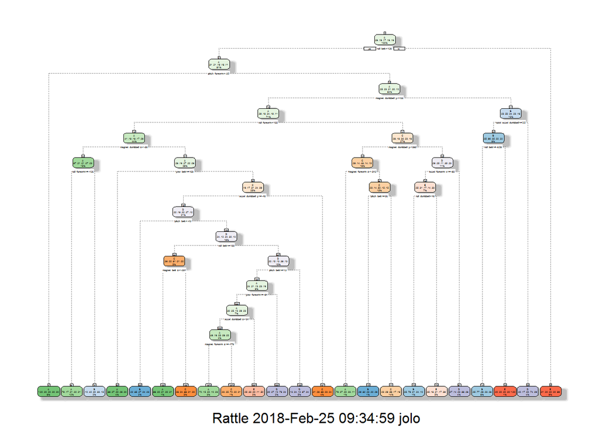

```r
library(rattle)
fancyRpartPlot(mod_tree)
```

## Random forest

```r
library(randomForest)
mod_rf <- randomForest(classe ~., data=trainset, method="class")
pred_rf <- predict(mod_rf, testset, type="class")
confusionMatrix(pred_rf, testset$classe)#$overall[1]
```

```
## Confusion Matrix and Statistics
##
##           Reference
## Prediction    A    B    C    D    E
##          A 2231   12    0    0    0
##          B    0 1501    9    0    0
##          C    0    5 1354   22    2
##          D    1    0    5 1262    2
##          E    0    0    0    2 1438
##
## Overall Statistics
##
##                Accuracy : 0.9924
##                  95% CI : (0.9902, 0.9942)
##     No Information Rate : 0.2845
##     P-Value [Acc > NIR] : < 2.2e-16
##
##                   Kappa : 0.9903
##  Mcnemar's Test P-Value : NA
##
## Statistics by Class:
##
##                      Class: A Class: B Class: C Class: D Class: E
## Sensitivity            0.9996   0.9888   0.9898   0.9813   0.9972
## Specificity            0.9979   0.9986   0.9955   0.9988   0.9997
## Pos Pred Value         0.9947   0.9940   0.9790   0.9937   0.9986
## Neg Pred Value         0.9998   0.9973   0.9978   0.9964   0.9994
## Prevalence             0.2845   0.1935   0.1744   0.1639   0.1838
## Detection Rate         0.2843   0.1913   0.1726   0.1608   0.1833
## Detection Prevalence   0.2859   0.1925   0.1763   0.1619   0.1835
## Balanced Accuracy      0.9987   0.9937   0.9926   0.9901   0.9985
```

*99% using random forest.* That’s way better!

Out of curiosity, let’s see which features were the most useful in predicting classe:

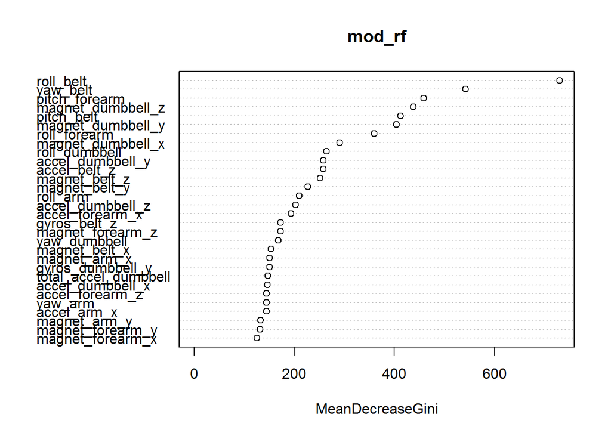

```
##  [1] 20 44 46 33  5 17 43  6  8 18  9 45 19 31 23 48 22 42 15 26 28  4 50
## [24] 51 25 21 16 49 34 30 32 24 11 29 52  7 47 36 14 12 13 10 35 27 37 40
## [47] 38  2 39 41  3  1
```

```r
order(varImpPlot(mod_rf, decreasing=T))
```

# Quiz answers

I’m quite pleased with the effectiveness of the rf model. I will use it to answer questions in the quiz

```r
valid_pred_rf <- predict(mod_rf, validation3 )
valid_pred_rf
```

```
##  1  2  3  4  5  6  7  8  9 10 11 12 13 14 15 16 17 18 19 20
##  B  A  B  A  A  E  D  B  A  A  B  C  B  A  E  E  A  B  B  B
## Levels: A B C D E
```

I submitted these answers and got perfect score. YAY!

# Appendices

A1) Exploratory Research

```
##        X            user_name    raw_timestamp_part_1 raw_timestamp_part_2
##  Min.   :    1   adelmo  :3892   Min.   :1.322e+09    Min.   :   294
##  1st Qu.: 4906   carlitos:3112   1st Qu.:1.323e+09    1st Qu.:252912
##  Median : 9812   charles :3536   Median :1.323e+09    Median :496380
##  Mean   : 9812   eurico  :3070   Mean   :1.323e+09    Mean   :500656
##  3rd Qu.:14717   jeremy  :3402   3rd Qu.:1.323e+09    3rd Qu.:751891
##  Max.   :19622   pedro   :2610   Max.   :1.323e+09    Max.   :998801
##
##           cvtd_timestamp  new_window    num_window      roll_belt
##  28/11/2011 14:14: 1498   no :19216   Min.   :  1.0   Min.   :-28.90
##  05/12/2011 11:24: 1497   yes:  406   1st Qu.:222.0   1st Qu.:  1.10
##  30/11/2011 17:11: 1440               Median :424.0   Median :113.00
##  05/12/2011 11:25: 1425               Mean   :430.6   Mean   : 64.41
##  02/12/2011 14:57: 1380               3rd Qu.:644.0   3rd Qu.:123.00
##  02/12/2011 13:34: 1375               Max.   :864.0   Max.   :162.00
##  (Other)         :11007
##    pitch_belt          yaw_belt       total_accel_belt kurtosis_roll_belt
##  Min.   :-55.8000   Min.   :-180.00   Min.   : 0.00             :19216
##  1st Qu.:  1.7600   1st Qu.: -88.30   1st Qu.: 3.00    #DIV/0!  :   10
##  Median :  5.2800   Median : -13.00   Median :17.00    -1.908453:    2
##  Mean   :  0.3053   Mean   : -11.21   Mean   :11.31    -0.016850:    1
##  3rd Qu.: 14.9000   3rd Qu.:  12.90   3rd Qu.:18.00    -0.021024:    1
##  Max.   : 60.3000   Max.   : 179.00   Max.   :29.00    -0.025513:    1
##                                                        (Other)  :  391
##  kurtosis_picth_belt kurtosis_yaw_belt skewness_roll_belt
##           :19216            :19216              :19216
##  #DIV/0!  :   32     #DIV/0!:  406     #DIV/0!  :    9
##  47.000000:    4                       0.000000 :    4
##  -0.150950:    3                       0.422463 :    2
##  -0.684748:    3                       -0.003095:    1
##  -1.750749:    3                       -0.010002:    1
##  (Other)  :  361                       (Other)  :  389
##  skewness_roll_belt.1 skewness_yaw_belt max_roll_belt     max_picth_belt
##           :19216             :19216     Min.   :-94.300   Min.   : 3.00
##  #DIV/0!  :   32      #DIV/0!:  406     1st Qu.:-88.000   1st Qu.: 5.00
##  0.000000 :    4                        Median : -5.100   Median :18.00
##  -2.156553:    3                        Mean   : -6.667   Mean   :12.92
##  -3.072669:    3                        3rd Qu.: 18.500   3rd Qu.:19.00
##  -6.324555:    3                        Max.   :180.000   Max.   :30.00
##  (Other)  :  361                        NA's   :19216     NA's   :19216
```

[output cut: 313 more lines]

```
##  Min.   :-446.00   Min.   :-1280.0   Min.   :-896.0   Min.   :-973.0
##  1st Qu.:-182.00   1st Qu.: -616.0   1st Qu.:   2.0   1st Qu.: 191.0
##  Median : -39.00   Median : -378.0   Median : 591.0   Median : 511.0
##  Mean   : -55.29   Mean   : -312.6   Mean   : 380.1   Mean   : 393.6
##  3rd Qu.:  26.00   3rd Qu.:  -73.0   3rd Qu.: 737.0   3rd Qu.: 653.0
##  Max.   : 291.00   Max.   :  672.0   Max.   :1480.0   Max.   :1090.0
##
##  classe
##  A:5580
##  B:3797
##  C:3422
##  D:3216
##  E:3607
##
##
```

```
##   X user_name raw_timestamp_part_1 raw_timestamp_part_2   cvtd_timestamp
## 1 1  carlitos           1323084231               788290 05/12/2011 11:23
## 2 2  carlitos           1323084231               808298 05/12/2011 11:23
## 3 3  carlitos           1323084231               820366 05/12/2011 11:23
## 4 4  carlitos           1323084232               120339 05/12/2011 11:23
## 5 5  carlitos           1323084232               196328 05/12/2011 11:23
##   new_window num_window roll_belt pitch_belt yaw_belt total_accel_belt
## 1         no         11      1.41       8.07    -94.4                3
## 2         no         11      1.41       8.07    -94.4                3
## 3         no         11      1.42       8.07    -94.4                3
## 4         no         12      1.48       8.05    -94.4                3
## 5         no         12      1.48       8.07    -94.4                3
##   kurtosis_roll_belt kurtosis_picth_belt kurtosis_yaw_belt
## 1
## 2
```

[output cut: 225 more lines]

```
##   X user_name raw_timestamp_part_1 raw_timestamp_part_2   cvtd_timestamp
## 1 1     pedro           1323095002               868349 05/12/2011 14:23
## 2 2    jeremy           1322673067               778725 30/11/2011 17:11
## 3 3    jeremy           1322673075               342967 30/11/2011 17:11
## 4 4    adelmo           1322832789               560311 02/12/2011 13:33
## 5 5    eurico           1322489635               814776 28/11/2011 14:13
##   new_window num_window roll_belt pitch_belt yaw_belt total_accel_belt
## 1         no         74    123.00      27.00    -4.75               20
## 2         no        431      1.02       4.87   -88.90                4
## 3         no        439      0.87       1.82   -88.50                5
## 4         no        194    125.00     -41.60   162.00               17
## 5         no        235      1.35       3.33   -88.60                3
##   kurtosis_roll_belt kurtosis_picth_belt kurtosis_yaw_belt
## 1                 NA                  NA                NA
## 2                 NA                  NA                NA
```

[output cut: 225 more lines]

A2) Check for factor variables

```
## 'data.frame':    19622 obs. of  86 variables:
##  $ roll_belt              : num  1.41 1.41 1.42 1.48 1.48 1.45 1.42 1.42 1.43 1.45 ...
##  $ pitch_belt             : num  8.07 8.07 8.07 8.05 8.07 8.06 8.09 8.13 8.16 8.17 ...
##  $ yaw_belt               : num  -94.4 -94.4 -94.4 -94.4 -94.4 -94.4 -94.4 -94.4 -94.4 -94.4 ...
##  $ total_accel_belt       : int  3 3 3 3 3 3 3 3 3 3 ...
##  $ kurtosis_roll_belt     : Factor w/ 397 levels "","-0.016850",..: 1 1 1 1 1 1 1 1 1 1 ...
##  $ kurtosis_picth_belt    : Factor w/ 317 levels "","-0.021887",..: 1 1 1 1 1 1 1 1 1 1 ...
##  $ kurtosis_yaw_belt      : Factor w/ 2 levels "","#DIV/0!": 1 1 1 1 1 1 1 1 1 1 ...
##  $ skewness_roll_belt     : Factor w/ 395 levels "","-0.003095",..: 1 1 1 1 1 1 1 1 1 1 ...
##  $ skewness_roll_belt.1   : Factor w/ 338 levels "","-0.005928",..: 1 1 1 1 1 1 1 1 1 1 ...
##  $ skewness_yaw_belt      : Factor w/ 2 levels "","#DIV/0!": 1 1 1 1 1 1 1 1 1 1 ...
##  $ max_yaw_belt           : Factor w/ 68 levels "","-0.1","-0.2",..: 1 1 1 1 1 1 1 1 1 1 ...
##  $ min_yaw_belt           : Factor w/ 68 levels "","-0.1","-0.2",..: 1 1 1 1 1 1 1 1 1 1 ...
##  $ amplitude_yaw_belt     : Factor w/ 4 levels "","#DIV/0!","0.00",..: 1 1 1 1 1 1 1 1 1 1 ...
##  $ gyros_belt_x           : num  0 0.02 0 0.02 0.02 0.02 0.02 0.02 0.02 0.03 ...
```

[output cut: 72 more lines]

A3) Check for Near Zero Variables

```
##                           freqRatio percentUnique zeroVar   nzv
## roll_belt                  1.101904     6.7781062   FALSE FALSE
## pitch_belt                 1.036082     9.3772296   FALSE FALSE
## yaw_belt                   1.058480     9.9734991   FALSE FALSE
## total_accel_belt           1.063160     0.1477933   FALSE FALSE
## kurtosis_roll_belt      1921.600000     2.0232392   FALSE  TRUE
## kurtosis_picth_belt      600.500000     1.6155336   FALSE  TRUE
## skewness_roll_belt      2135.111111     2.0130466   FALSE  TRUE
## skewness_roll_belt.1     600.500000     1.7225563   FALSE  TRUE
## max_yaw_belt             640.533333     0.3465498   FALSE  TRUE
## min_yaw_belt             640.533333     0.3465498   FALSE  TRUE
## gyros_belt_x               1.058651     0.7134849   FALSE FALSE
## gyros_belt_y               1.144000     0.3516461   FALSE FALSE
## gyros_belt_z               1.066214     0.8612782   FALSE FALSE
## accel_belt_x               1.055412     0.8357966   FALSE FALSE
## accel_belt_y               1.113725     0.7287738   FALSE FALSE
## accel_belt_z               1.078767     1.5237998   FALSE FALSE
## magnet_belt_x              1.090141     1.6664968   FALSE FALSE
## magnet_belt_y              1.099688     1.5187035   FALSE FALSE
## magnet_belt_z              1.006369     2.3290184   FALSE FALSE
## roll_arm                  52.338462    13.5256345   FALSE FALSE
## pitch_arm                 87.256410    15.7323412   FALSE FALSE
## yaw_arm                   33.029126    14.6570176   FALSE FALSE
## total_accel_arm            1.024526     0.3363572   FALSE FALSE
## gyros_arm_x                1.015504     3.2769341   FALSE FALSE
## gyros_arm_y                1.454369     1.9162165   FALSE FALSE
## gyros_arm_z                1.110687     1.2638875   FALSE FALSE
## accel_arm_x                1.017341     3.9598410   FALSE FALSE
## accel_arm_y                1.140187     2.7367241   FALSE FALSE
## accel_arm_z                1.128000     4.0362858   FALSE FALSE
## magnet_arm_x               1.000000     6.8239731   FALSE FALSE
## magnet_arm_y               1.056818     4.4439914   FALSE FALSE
## magnet_arm_z               1.036364     6.4468454   FALSE FALSE
## kurtosis_roll_arm        246.358974     1.6817858   FALSE  TRUE
## kurtosis_picth_arm       240.200000     1.6715931   FALSE  TRUE
## kurtosis_yaw_arm        1746.909091     2.0130466   FALSE  TRUE
## skewness_roll_arm        249.558442     1.6868821   FALSE  TRUE
## skewness_pitch_arm       240.200000     1.6715931   FALSE  TRUE
## skewness_yaw_arm        1746.909091     2.0130466   FALSE  TRUE
## roll_dumbbell              1.022388    84.2065029   FALSE FALSE
```

[output cut: 23 more lines]

```
## skewness_roll_forearm    231.518072     1.6461115   FALSE  TRUE
## skewness_pitch_forearm   226.070588     1.6257262   FALSE  TRUE
## max_yaw_forearm          228.761905     0.2293344   FALSE  TRUE
## min_yaw_forearm          228.761905     0.2293344   FALSE  TRUE
## total_accel_forearm        1.128928     0.3567424   FALSE FALSE
## gyros_forearm_x            1.059273     1.5187035   FALSE FALSE
## gyros_forearm_y            1.036554     3.7763735   FALSE FALSE
## gyros_forearm_z            1.122917     1.5645704   FALSE FALSE
## accel_forearm_x            1.126437     4.0464784   FALSE FALSE
## accel_forearm_y            1.059406     5.1116094   FALSE FALSE
## accel_forearm_z            1.006250     2.9558659   FALSE FALSE
## magnet_forearm_x           1.012346     7.7667924   FALSE FALSE
## magnet_forearm_y           1.246914     9.5403119   FALSE FALSE
## magnet_forearm_z           1.000000     8.5771073   FALSE FALSE
## classe                     1.469581     0.0254816   FALSE FALSE
```